# STAT 441: Introduction to R and Statistics Review

## Learning Objectives:

In this lesson students will learn …

- The basics of R
- Plotting in base R
- Optional: plotting with ggplot

Students will also review important concepts in statistics, such as …

- Parameters,
- Statistics,
- Estimation, and
- Convergence
- Important Theorems

## 1. Variable Assignment

In R you can use the equals sign `=` or the arrow `<-` to do variable assignment.

```r
### CREATE A CONSTANT VARIABLE NAMED "A"
### PICK YOUR FAVORITE NUMBER!
A <- 5
```

## 2. Distributions in R

There are several distributions built into base R, from which you can draw values.

### A. Generate

Let’s generate 10 values from `rnorm`.

```r
### GENERATE 10 VALUES FROM rnorm
rnorm(n=10)
```

```
##  [1]  0.06371599 -1.69917235 -0.81334074  1.59402124  0.82178761 -0.99798540
##  [7]  0.65926386 -0.38326540 -1.01800215 -1.85245315
```

##### Question

Compare your values with a partner. Are they the same or different?

```
## YOUR NOTES HERE ##
```

### B. Setting A Seed

You may have observed that every time you run the `rnorm` function that it will give you different values. This is because the “r” in `rnorm` stands for “random” and thereby is a (pseudo) random number generator. We can set a seed to tell the computer where to start the algorithm.

```r
### SET A SEED
set.seed(441)

### TRY AGAIN
### GENERATE 10 VALUES FROM rnorm
rnorm(n=10)
```

```
##  [1]  1.3251847  0.5448521  2.1849953 -1.0778856 -1.0796559 -0.2480446
##  [7] -2.2067853  0.8508706 -1.7793107 -2.0708579
```

Setting a seed helps with making your code reproducible!

### C. Functions in R and Documentation

Let’s take a moment to learn about this function.

```r
### READ THE DOCUMENTATION FOR THE rnorm
?rnorm
help(rnorm)
```

##### Question

What does rnorm do?

```
## YOUR NOTES HERE ##
```

### D. Arguments

In R we call the function inputs “arguments”. The arguments for the `rnorm` function are:

- `n`: number of observations
- `mean`: center of the distribution
- `sd`: standard deviation of the distribution (spread)

##### Question

What are the default arguments for `rnorm`?

BONUS: What is the special name of this distribution?

```
## YOUR NOTES HERE ##
```

The normal distribution has two parameters:

- Mean ($\mu \in \mathbb{R}$)
- Standard deviation ($\sigma \in \mathbb{R^+}$)

Parameters are numeric values that describe a characteristic of a population. In the frequentist paradigm, parameters are considered to be fixed and unknown.

##### Activity

Let’s explore this by sampling 100 individuals from a population, where the variable of interest follows a normal distribution with a mean of 4 and a standard deviation of 2. Since we are going to use this data for later, we will want to store it as a variable named “X”.

```r
### SAMPLE 100
### MEAN = 4
### SD = 2

### REMEMBER TO STORE
X<-rnorm(n=100, mean=4, sd=2)
```

Look at the data generated with a histogram using the base R graphics function `hist()`.

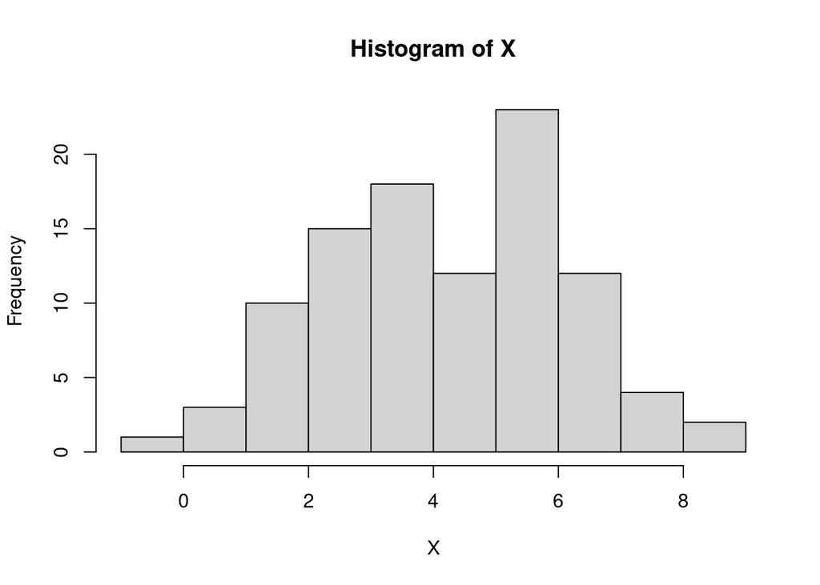

```r
### HISTOGRAM
hist(X)
```

##### Question

Where does the center of the distribution appear to be?

```
## YOUR NOTES HERE ##
```

## 3. Parameters and Statistics

Since parameters are unknown, we try to estimate them by collecting a **sample** of data from the **target population** and calculating **statistics**. Statistics are simply functions of data.

For instance, the arithmetic mean ($\bar{x}$) is known as the *sample mean* and is used to estimate the population mean ($\mu$).

$$\bar{x}_n=\frac{1}{n}\sum_{i=1}^n
x_i$$

##### Activity

Calculate the sample mean of the data generated above.

```r
### SAMPLE MEAN
mean(X)
```

```
## [1] 4.181676
```

In general, it is desired that estimators be **unbiased**. An estimator is unbiased if the **expected value** of the estimator is equal to the true value of parameter.

## 4. Important Theorems

### A. Law of Large Numbers

Simply put, the *Law of Large Numbers* (LLN) states that as the sample size ($n$) increases,

$$\bar{x}_n \rightarrow \mu, \text{ as } n
\rightarrow \infty$$
##### Activity

Try it out!

```r
### SMALLER SAMPLE
x10<-rnorm(n=10, mean=4, sd=2)
mean(x10)
```

```
## [1] 2.779277
```

```r
### BIGGER SAMPLE
x500<-rnorm(n=500, mean=4, sd=2)
mean(x500)
```

```
## [1] 4.021584
```

We can do better. Let’s simulate!

##### Simulation

We can loop this using different sample sizes to observe the Law of Large Numbers (LLN) in action:

```r
### LLN
nsamp<-1:1000
xBars<-c()

for(i in 1:length(nsamp)){
  thisSamp<-rnorm(n=nsamp[i], mean=4, sd=2)
  thisXBar<-mean(thisSamp)

  ### CONCATINATE!
  xBars<-c(xBars, thisXBar)
}
```

We can visualize this in two ways: (1) Base R graphics and (2) `ggplot`

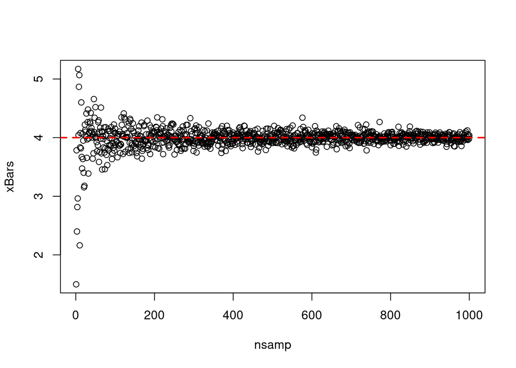

```r
### BASE R GRAPHICS
plot(nsamp, xBars)
abline(h=4, col="red", lty=2, lwd=2)
```

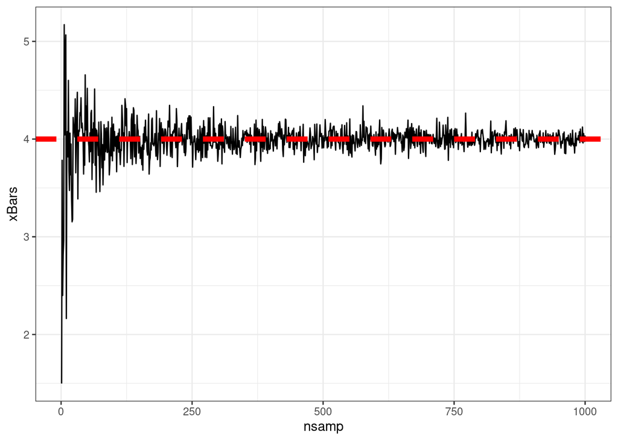

```r
### FIRST: MAKE A DATAFRAME
llnSim<-data.frame(nsamp, xBars)

### SECOND: GGPLOT
#install.packages("tidyverse")
library(tidyverse)

ggplot(data=llnSim, aes(x=nsamp, y=xBars))+
  geom_line()+
  geom_hline(yintercept = 4, lwd=2, lty=2, color="red")+
  theme_bw()
```

### B. Central Limit Theorem

The Central Limit Theorem (CLT) is probably the most commonly used theorem in statistics. It states that as the sample size ($n$) increases,

$$\bar{x}_n \rightarrow
N(\mu,\frac{\sigma}{\sqrt{n}}), \text{ as } n \rightarrow
\infty$$

regardless of the underlying distribution.

##### Activity

Step 1: Generate Data

In order to demonstrate the power of the CLT we will generate data from differently shaped distributions, with the same mean.

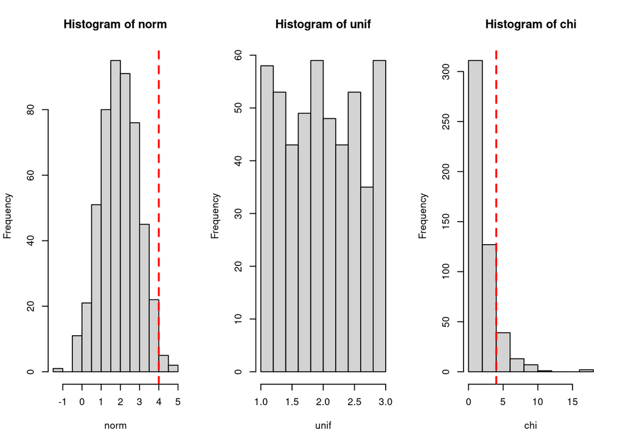

```r
### NORMAL (MEAN=4, SD=2)
norm<-rnorm(n=500, mean=2, sd=1)

### UNIFORM (MIN=2, MAX=6)
unif<-runif(n=500, min=1, max=3)

### CHI-SQUARE (DF=4)
chi<-rchisq(n=500, df=2)

### GRAPHICS IN BASE R
### PLOT IN ONE ROW
par(mfrow=c(1,3)) # PLOTS THREE BASE R GRAPHICS IN A ROW
hist(norm)
abline(v=4, col="red", lwd=2, lty=2)

hist(unif)
abline(v=4, col="red", lwd=2, lty=2)

hist(chi)
abline(v=4, col="red", lwd=2, lty=2)
```

```r
par(mfrow=c(1,1)) ## RESET BACK TO NORMAL
```

##### Question

How would you describe the spaces of these distributions?

```
## YOUR NOTES HERE ##
```

We can also create a graphic using `ggplot`.

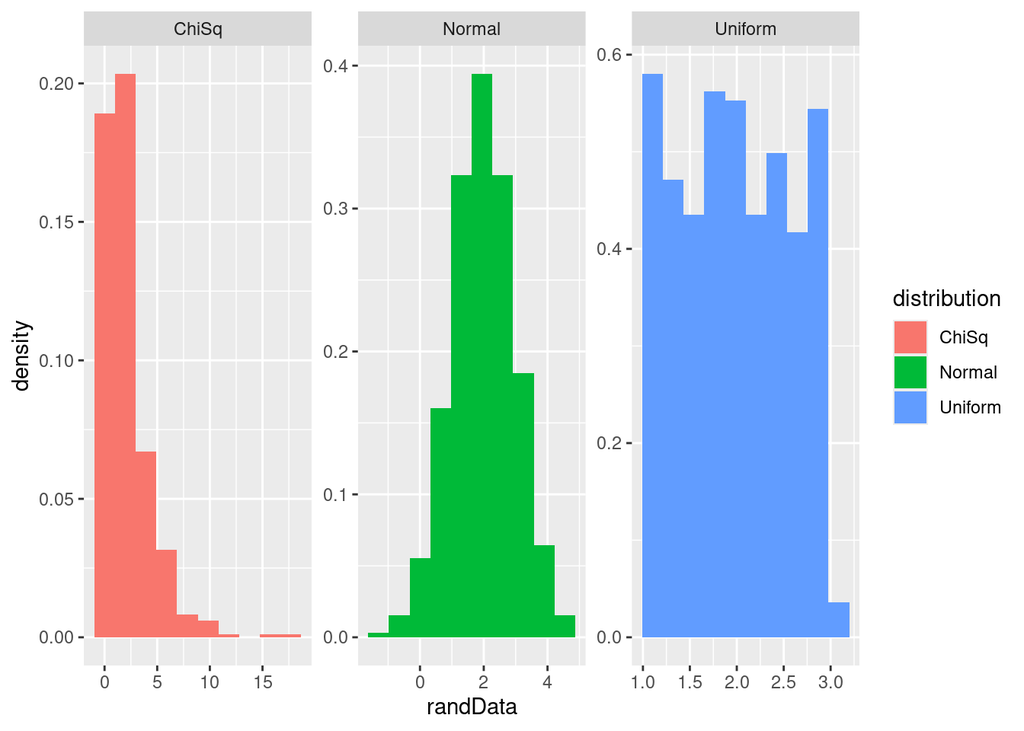

```r
### GRAPHICS IN GGPLOT

### FIRST MAKE A DATAFRAME
dist_DF<-data.frame(distribution=c(rep("Normal", 500),
                                   rep("Uniform", 500),
                                   rep("ChiSq", 500)),
                    randData=c(norm, unif, chi))

### GGPLOT WITH FACET
ggplot(data=dist_DF, aes(x=randData, fill=distribution))+
  geom_histogram(aes(y=after_stat(density)), bins=10)+
  facet_wrap(.~distribution, scales="free")
```

##### Question

What do you notice about how these plots are ordered? What does this tell you about how are treats categorical variables?

```
## YOUR NOTES HERE ##
```

##### Simulation

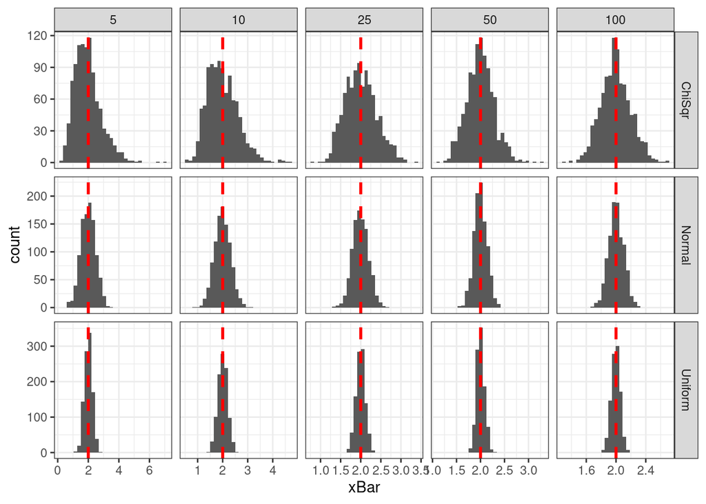

```r
### SAMPLE SIZES
nsim<-1000
nSamps<-c(5, 10, 25, 50, 100)

### CREATE A BLANK MATRIX TO STORE DATA
normXBar<-matrix(nrow=nsim*length(nSamps),
                 ncol=4)

unifXBar<-matrix(nrow=nsim*length(nSamps),
                 ncol=4)

chiXBar<-matrix(nrow=nsim*length(nSamps),
                 ncol=4)

for(i in 1:length(nSamps)){
  for(j in 1:nsim){
    thisNorm<-rnorm(n=nSamps[i], mean=2, sd=1)
    thisUnif<-runif(n=nSamps[i], min=1, max=3)
    thisChi<-rchisq(n=nSamps[i], df=2)

    ### STORE THE SIMULATION DATA
    row<-j+(i-1)*nsim

    ### SIMULATION
    normXBar[row, 1]<-j
    unifXBar[row, 1]<-j
    chiXBar[row, 1]<-j

    ### SAMPLE SIZE
    normXBar[row, 2]<- nSamps[i]
    unifXBar[row, 2]<- nSamps[i]
    chiXBar[row, 2]<- nSamps[i]

    ### SAMPLE MEAN
    normXBar[row, 3]<-mean(thisNorm)
    unifXBar[row, 3]<-mean(thisUnif)
    chiXBar[row, 3]<-mean(thisChi)

    ### DISTRIBUTION
     normXBar[row, 4]<-"Normal"
    unifXBar[row, 4]<-"Uniform"
    chiXBar[row, 4]<-"ChiSqr"
  }
}

### ROW BIND DATA FROM DIFFERENT DISTRIBUTIONS
simMat<-rbind(normXBar, unifXBar, chiXBar)
colnames(simMat)<-c("Sim", "SampSize", "xBar", "Distribution")

### REFORMAT TO DATAFRAME
simDat<-as.data.frame(simMat)

### COERCE VARIABLES TO NUMERICS
simDat$SampSize<-as.numeric(simDat$SampSize)
simDat$xBar<-as.numeric(simDat$xBar)

### GGPLOT
ggplot(simDat, aes(x=xBar))+
  geom_histogram()+
  geom_vline(xintercept = 2, color="red", lty=2, lwd=1)+
  facet_grid(Distribution~SampSize, scales="free")+
  theme_bw()
```